# The (Data) Science of Dataviz

## *Romain Vuillemot*

[figure not shown]

[@romsson](https://twitter.com/romsson)

http://romain.vuillemot.net/

*Notes for a talk given during the [Lyon Data Science meetup](http://www.meetup.com/Lyon-Data-Science/events/227856813/)*

*Notebook https://github.com/romsson/lyon-meetup-data-science-dataviz*

## http://romain.vuillemot.net/

[figure not shown]

*A full list of my projects and publications is availble at http://romain.vuillemot.net/ with related code source and materials (usually videos and screenshots). And of course interactive prototype you can play with.*

## The Globe of Economic Complexity

[figure not shown]

*The Globe of Economic Complexity visualizes 15 trillion dollars of world trade. One dot equals 100 million dollars of exported products. It uses Three.js & WebGL. Check it out: http://globe.cid.harvard.edu/.*

## El Atlas de Complejidad Económica de México *Mexican Atlas of Economic Complexity*

[figure not shown]

*The Mexican Atlas of Economic Complexity is a diagnostic tool that firms, investors and policymakers can use to improve the productivity of states, cities and municipalities. Check it out: http://complejidad.datos.gob.mx/*

By the way you can view, download or [re-compile](http://www.slideviper.oquanta.info/tutorial/slideshow_tutorial_slides.html#/11) this presentation:

```
> ipython nbconvert --to slides data-science-dataviz.ipynb --post serve
```

Want to see the source code? Fix a typo? Re-use? https://github.com/romsson/lyon-meetup-data-science-dataviz

# What is data visualization?

## (pre)-Historical Example

[figure not shown]

[Kish tablet](https://en.wikipedia.org/wiki/Kish_tablet) with proto-cuneiform signs dated to ca. 3500 BC.

## William Playfair

[figure not shown]

Exports and imports to and form Denmark & Norway from 1700 to 1780

## Joseph Minard

[figure not shown]

Carte figurative des pertes successives en hommes de l'Armée Française dans la campagne de Russie 1812-1813 https://en.wikipedia.org/wiki/Charles_Joseph_Minard

## Joseph Minard

[figure not shown]

Carte figurative et approximative des quantités de viandes de boucherie envoyées sur pied par les départements et consommateurs à Paris. source: https://en.wikipedia.org/wiki/Charles_Joseph_Minard

## John Snow

[figure not shown]

Cholera cases in the London epidemic of 1854 https://en.wikipedia.org/wiki/John_Snow_(physician)

# E. J. Marey

[figure not shown]

E. J. Marey's graphical schedule shows actual speed of trains with the slop of the line: the steeper the line, the faster the train.

## Jacques Bertin

[video not shown]

*[Jacques Bertin](https://en.wikipedia.org/wiki/Jacques_Bertin) (1918 – 2010) was a French cartographer and theorist, known from his book Semiologie Graphique (Semiology of Graphics), published in 1967.*

More details on data visualization milestones and [historical examples](http://www.t-o-m-b-o-l-o.eu/meta/histoire-de-tourner-en-rond-breves-cousues-main-du-fromage-normand-a-barack-obama-2/).

# Why visualize?

## Example #1

Find the minimal value for the following equation:

$1.3 x^2 + 4 x + 0.6$

Let's just automatically find the minimal value using `scipy`

```python
import numpy as np
import scipy.optimize as opt

objective = np.poly1d([1.3, 4.0, 0.6])
x_ = opt.fmin(objective, [3])
print("solved: x={}".format(x_))
```

```
Optimization terminated successfully.
         Current function value: -2.476923
         Iterations: 20
         Function evaluations: 40
solved: x=[-1.53845215]
```

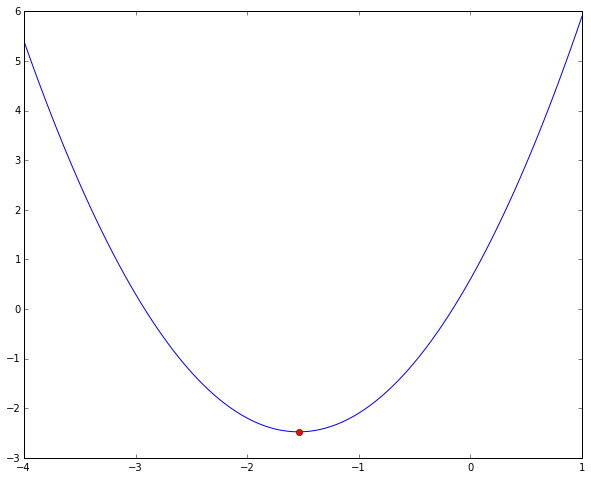

```python
%matplotlib inline
import matplotlib.pylab as plt
from ipywidgets import widgets
from IPython.display import display

x = np.linspace(-4, 1, 101.)
fig = plt.figure(figsize=(10, 8))
plt.plot(x, objective(x))
plt.plot(x_, objective(x_), 'ro')
plt.show()
```

## Example #2

Find interesting patterns in those 4 datasets with eleven (x,y) points.

| I |  | II |  | III |  | IV |  |
| --- | --- | --- | --- | --- | --- | --- | --- |
| x | y | x | y | x | y | x | y |
| 10.0 | 8.04 | 10.0 | 9.14 | 10.0 | 7.46 | 8.0 | 6.58 |
| 8.0 | 6.95 | 8.0 | 8.14 | 8.0 | 6.77 | 8.0 | 5.76 |
| 13.0 | 7.58 | 13.0 | 8.74 | 13.0 | 12.74 | 8.0 | 7.71 |
| 9.0 | 8.81 | 9.0 | 8.77 | 9.0 | 7.11 | 8.0 | 8.84 |
| 11.0 | 8.33 | 11.0 | 9.26 | 11.0 | 7.81 | 8.0 | 8.47 |
| 14.0 | 9.96 | 14.0 | 8.10 | 14.0 | 8.84 | 8.0 | 7.04 |
| 6.0 | 7.24 | 6.0 | 6.13 | 6.0 | 6.08 | 8.0 | 5.25 |
| 4.0 | 4.26 | 4.0 | 3.10 | 4.0 | 5.39 | 19.0 | 12.50 |
| 12.0 | 10.84 | 12.0 | 9.13 | 12.0 | 8.15 | 8.0 | 5.56 |
| 7.0 | 4.82 | 7.0 | 7.26 | 7.0 | 6.42 | 8.0 | 7.91 |
| 5.0 | 5.68 | 5.0 | 4.74 | 5.0 | 5.73 | 8.0 | 6.89 |

The [Anscombe's quartet](https://en.wikipedia.org/wiki/Anscombe%27s_quartet).

All points nearly have **identical** simple statistical properties:

| Property | Value |
| --- | --- |
| Mean of x | 9 |
| Sample variance of x | 11 |
| Mean of y | 7.50 |
| Sample variance of y | 4.122 |
| Correlation | 0.816 |
| Linear regression line | y = 3.00 + 0.500x |

Not so identical, **visually**.

[figure not shown]

# Why is it difficult?

Take some time finding the best way to visually represent those two quantities:

75 37

See the full list in [45 Ways to communicate two quantities](http://blog.visual.ly/45-ways-to-communicate-two-quantities/) by Santiago Ortiz

## Visualization as.. a combinatorial problem

Line, Circle, Rectangle, .. (Graphical Marks)

$\times$ Position, Size, Color, .. (Properties)

$\times$ Selection, Binning, Aggregation, .. (Data transformation)

$=$ Huge number of permutations (even for small and simple datasets)

## What to optimize? How to evaluate?

- Some principles allow to reduce the size of the space and directly jump to interesting points
- Otherwise, **no automatic rules** to generate a visualization: each visualization has a specific role, efficiency in a given **context**.

## Gestalt / theories of visual perception

Humans visual system has a natural hability to generate similarity, continuation, closure, etc. among visual elements.

[figure not shown]

## Chart junk

Uncessary (?) use of decorations/ornament that can impair readability (but increase engagement, memorability, branding).

[figure not shown]

R.Kosara [Want to Make A Chart Memorable? Add Junk](https://eagereyes.org/blog/2011/want-to-make-chart-memorable-add-junk)

## Aesthetic

[figure not shown]

Andrew Vande Moere, Helen Purchase. [*On the role of design in information visualization.*](http://infoscape.org/publications/ivs12.pdf)

# Graphical Marks & Properties

## Marks and properties list

[figure not shown]

Bertin, Jacques. "Semiology of graphics: diagrams, networks, maps." (1967).

## Marks and properties variations

[figure not shown]

Bertin, Jacques. "Semiology of graphics: diagrams, networks, maps." (1967).

## Ranking of graphical marks

[figure not shown]

*Mackinlay, Jock. ["Automating the design of graphical presentations of relational information."](http://www2.parc.com/istl/groups/uir/publications/items/UIR-1986-02-Mackinlay-TOG-Automating.pdf) Acm Transactions On Graphics (Tog) 5.2 (1986): 110-141.*

## Ranking of graphical marks by data type

[figure not shown]

*Mackinlay, Jock. ["Automating the design of graphical presentations of relational information."](http://www2.parc.com/istl/groups/uir/publications/items/UIR-1986-02-Mackinlay-TOG-Automating.pdf) Acm Transactions On Graphics (Tog) 5.2 (1986): 110-141.*

## Example: Chloropleth maps

[figure not shown]

New-York Times elections 2016 [Iowa](http://www.nytimes.com/elections/2016/primaries/iowa) & [New Hampshire Results Exit Polls](http://www.nytimes.com/elections/2016/primaries/new-hampshire)

# Visual Mapping

## *from templates to customization*

## Visualization Templates (or Charts)

[figure not shown]

Visualization templates can be seen as pre-defined and (usually) well accepted combinations. See The Data Visualisation Catalogue http://www.datavizcatalogue.com/search.html.

## Google Visualization

[figure not shown]

https://developers.google.com/chart/interactive/docs/gallery

## Tableau Software: Show Me!

[figure not shown]

Mackinlay J, Hanrahan P, Stolte C. **Show me: automatic presentation for visual analysis.** IEEE Trans Vis Comput Graph. 2007 Nov-Dec;13(6):1137-44.

## Tableau Software: Drag & Drop

[figure not shown]

Tableau has a 10-12 year jump on Microsoft here and is a swiss army knife when it comes to data sources. Tableau does monthly updates as well with a big release or 2 every year. Still a much easier product to use and deploy at scale.

## Raw by designdensity

[video not shown]

[Raw - Basic Tutorial](https://vimeo.com/75866661) from [DensityDesign](https://vimeo.com/densitydesign) on [Vimeo](https://vimeo.com).

## Vega

[figure not shown]

Vega [charts configuration editor](http://vega.github.io/vega-editor/index.html?mode=vega&spec=bar). You borrow configuration from [existing templates](https://github.com/vega/vega/wiki/Marks). Extend them or override. JSON objects as configurations.

## Brunel

[figure not shown]

http://brunelvis.org/

# *Preparatory* Visualizations

## Trifacta Visual Profiler

https://www.trifacta.com/visual-profiling-for-data-transformation/

[figure not shown]

Trifacta data wrangler, shows most frequent values, outliers or potential variable transformations. http://vis.stanford.edu/papers/wrangler. See also Google Open Refine http://openrefine.org/.

# *Exploratory* Visualizations

## Matlibplot / Seaborn

(From http://stanford.edu/~mwaskom/software/seaborn-dev/tutorial/distributions.html)

```python
import numpy as np
from numpy.random import randn
import pandas as pd
from scipy import stats
import matplotlib as mpl
import matplotlib.pyplot as plt
import seaborn as sns
%matplotlib inline
```

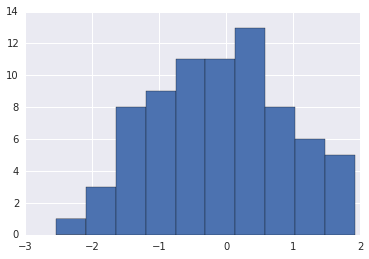

```python
data = randn(75)
plt.hist(data);
```

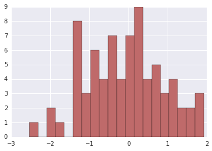

```python
plt.hist(data, 20, color=sns.desaturate("indianred", .75));
```

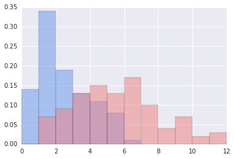

```python
data1 = stats.poisson(2).rvs(100)
data2 = stats.poisson(5).rvs(100)
max_data = np.r_[data1, data2].max()
bins = np.linspace(0, max_data, max_data + 1)
plt.hist(data1, bins, normed=True, color="#6495ED", alpha=.5)
plt.hist(data2, bins, normed=True, color="#F08080", alpha=.5);
```

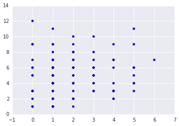

```python
plt.scatter(data1, data2)
```

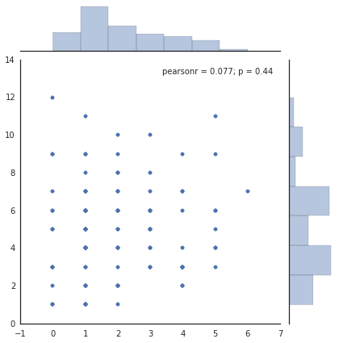

```python
with sns.axes_style("white"):
    sns.jointplot(data1, data2);
```

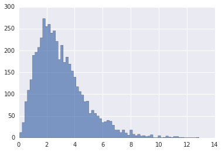

```python
x = stats.gamma(3).rvs(5000)
plt.hist(x, 70, histtype="stepfilled", alpha=.7);
```

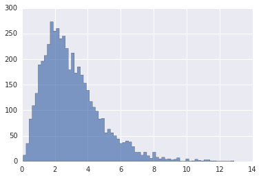

```python
y = stats.gamma(3).rvs(5000)
plt.hist(x, 70, histtype="stepfilled", alpha=.7);
```

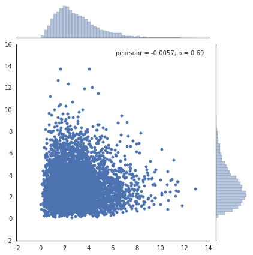

```python
with sns.axes_style("white"):
    sns.jointplot(x, y);
```

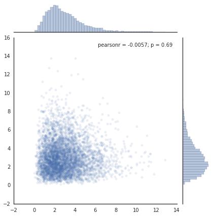

```python
with sns.axes_style("white"):
    sns.jointplot(x, y, alpha=.1);
```

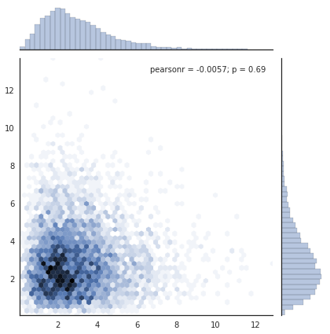

```python
with sns.axes_style("white"):
    sns.jointplot(x, y, kind="hex");
```

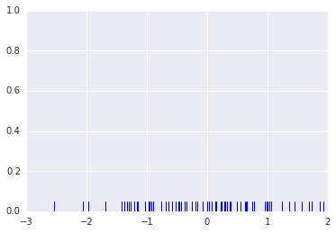

```python
sns.rugplot(data);
```

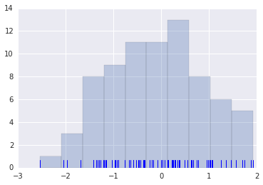

```python
plt.hist(data, alpha=.3)
sns.rugplot(data);
```

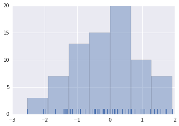

```python
sns.distplot(data, kde=False, rug=True);
```

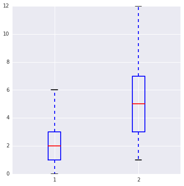

```python
sns.set(rc={"figure.figsize": (6, 6)})
data = [data1, data2]
plt.boxplot(data);
```

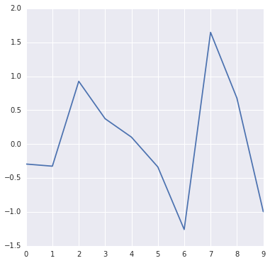

```python
normals = pd.Series(np.random.normal(size=10))
normals.plot()
```

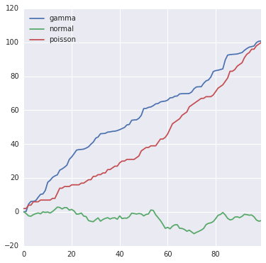

```python
variables = pd.DataFrame({'normal': np.random.normal(size=100),
                       'gamma': np.random.gamma(1, size=100),
                       'poisson': np.random.poisson(size=100)})
variables.cumsum(0).plot()
```

[output not shown]

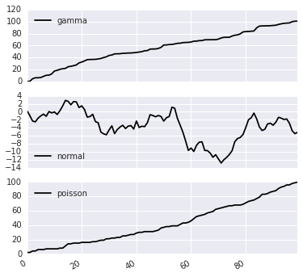

```python
variables.cumsum(0).plot(subplots=True)
```

## Data Voyager

[figure not shown]

[Data Voyager](http://vega.github.io/voyager/) automatically generates charts with no input by default (besides loading the dataset). You can interact to get more details and bookmark them.

## Scatterplot Matrix

[figure not shown]

[D3 Scatterplot Matrix](http://bl.ocks.org/mbostock/raw/4063663/)

## Scatterplot Matrix Navigation

[figure not shown]

INSEE unemployement data exploration using INRIA ScatterDice http://labs.data-publica.com/emploi/. Multidimensional *Grand Tour* visualization.

## Machine Learning Classifier Comparison

[figure not shown]

[Plot.ly](https://plot.ly/~jackp/16209/machine-learning-classifier-comparison.embed)

# *Monitoring* Visualization

[interactive chart not shown]

## Sparklines

[figure not shown]

https://github.com/swingley/baseball-sparklines. Sparklines [design guidelines](http://www.edwardtufte.com/bboard/q-and-a-fetch-msg?msg_id=0001OR) and [best practices for dashboards](https://www.perceptualedge.com/articles/visual_business_intelligence/best_practices_for_scaling_sparklines.pdf)

# *Explanatory* Visualizations

## D3 & Co.

[figure not shown]

[d3](https://d3js.org/). Highchart, NVD3, Rickshaw + their framweork-specific charts (React, ember, ..) and [editor](http://tributary.io/inlet/4653053). See full list on http://keshif.me/demo/VisTools or http://www.jsgraphs.com/.

## Four Ways to Slice Obama’s 2013 Budget Proposal

[figure not shown]

http://www.nytimes.com/interactive/2012/02/13/us/politics/2013-budget-proposal-graphic.html

## Temperature, Humidity and Moisture Content (MC)

[figure not shown]

http://woodchanges.com/

## How the U.S. and OPEC Drive Oil Prices

[figure not shown]

http://www.nytimes.com/interactive/2015/09/30/business/how-the-us-and-opec-drive-oil-prices.html?_r=0

## A Visual Introduction to Machine Learning

[figure not shown]

A [Visual Introduction to Machine Learning](http://www.r2d3.us/visual-intro-to-machine-learning-part-1/) by R2D3

# *What if* Visualizations

## 512 Paths to the White House

[figure not shown]

http://www.nytimes.com/interactive/2012/11/02/us/politics/paths-to-the-white-house.html

## Champions League Predictions

[figure not shown]

http://predict.re/ucl/

## Birth rate models

[figure not shown]

http://flowingdata.com/2015/09/23/years-you-have-left-to-live-probably/

Years You Have Left to Live, Probably

## What Would It Take To Turn Red/Blue States Red/Blue?

[figure not shown]

http://projects.fivethirtyeight.com/2016-swing-the-election/

## Climate Change Calculator

[figure not shown]

http://ig.ft.com/sites/climate-change-calculator/

# Wrap-up

## *"Show data variations, not design variations"*

Edward Tufte

## Design is a Search Problem

[figure not shown]

[Design is a Search Problem](https://youtu.be/fThhbt23SGM?t=32m50s) OpenVis 2014. Animated Gif from [The Journalist-Engineer](https://d262ilb51hltx0.cloudfront.net/max/1600/1*NYCujc1c1gD9Ta5VrX0D7w.gif)

## Trends

- More advanced interactions combined with fast [server-side rendering](http://bokeh.pydata.org/en/latest/docs/gallery.html)
- More reproductive and collaborative dataviz
- Data journalism and [the U.S. elections](https://www.washingtonpost.com/graphics/politics/2016-election/primaries/new-hampshire-results-analysis/) for the next trends!
- WebGL / Three.js
- Virtual Reality dataviz

## Resources

Jobs

- `<data-vis-jobs@googlegroups.com>`

Social media

- Twitter [#dataviz](https://twitter.com/search?q=%23dataviz&src=typd)
- Twitter lists https://twitter.com/infobeautyaward/lists/data-visualisation-people
- LinkedIn topic https://www.linkedin.com/topic/dataviz
- Reddit data is beautiful (top 50 sub-reddit), internet is beautiful, some random [discussion thread](https://www.reddit.com/r/dataisbeautiful/comments/435g7b/i_love_live_data_visualizations_heres_every_one/)

Learn more